# JABBA3 on Indian Ocean blue shark

One working example. Change the marked block for another stock.

# Purpose

SS3 is not run here. A finished SS3 folder supplies catch and CPUE. JABBA3 is fitted to those series. The SS3 Kobe point in the same folder is one score; the 2017 IOTC JABBA result is the other.

Priors and fixed choices below follow the 2017 WPEB blue shark JABBA (IOTC–2017–WPEB13–31; summarised in the [supporting information](https://iotc.org/sites/default/files/documents/science/species_summaries/english/Blue_Shark_Supporting_Information.pdf) Table 3 and in IOTC–2017–WPM08–11).

This file is the worked example. For another stock, change only the marked block (and, if needed, how catch and CPUE are built). The steps after that stay the same.

Guide chapters: JABBA3 user guide — data, priors, model, fitting, diagnostics.

# 1. Inputs

```r
# --- stock and paths ---
stock_id <- "bsh-io"
ss3_dir  <- file.path("..", "data", "bsh-io")
# ss3_dir <- "P:/zbook/datasets/ss3/bsh-io"

# --- 2017 JABBA base CPUE (supporting info / WPEB13-31): Japan late, EU-Portugal, Réunion ---
# Sensitivity indices in the folder: S1_JPN_EARLY, S4_EU_ESP, S5_TAI, S6_IND, S8_ZAF
indices <- c("S2_JPN_LATE", "S3_EU_POR", "S7_REUNION")

# --- 2017 JABBA priors (Schaefer; means + CVs from WPM08-11) ---
# r ~ LN(0.267, CV 0.075); K ~ LN(600000 t, CV 200%); B1/K ~ LN(1, CV 0.25)
cv2lsd <- function(cv) sqrt(log(1 + cv^2))
r_prior  <- c(0.267, cv2lsd(0.075))
K_prior  <- c(600000, cv2lsd(2.0))
psi_prior <- c(1.0, cv2lsd(0.25))
shape    <- "schaefer"
sdb_prior <- "igamma"   # JABBA 2 legacy process-variance prior used in 2017
se_min   <- 0.25        # minimum observation error added in the 2017 runs
start_pe <- "index"     # process error from first index year (JABBA 2 proc.dev.all = FALSE)

# --- fit ---
ndraws <- 1000
run_id <- "bsh-io IOTC-2017 priors"
```

# 2. Setup

```r
if (!requireNamespace("JABBA3", quietly = TRUE)) {
  stop("Install JABBA3, e.g. remotes::install_local('C:/work/flr/02_others/JABBA3')")
}
library(JABBA3)

candidates <- c(
  ss3_dir,
  file.path("data", "bsh-io"),
  file.path("..", "data", "bsh-io"),
  "P:/zbook/datasets/ss3/bsh-io"
)
ss3_dir <- candidates[file.exists(file.path(candidates, "smry.RData"))][1]
if (is.na(ss3_dir)) {
  stop("smry.RData not found. Set ss3_dir to the SS3 folder.")
}
```

# 3. Extract catch and CPUE from SS3

For this example the SS3 folder already has `smry.RData` with:

- `smry$ts` — year and catch
- `smry$dg` — index name, year, and observed CPUE (`obs`)
- `smry$kb` — SS3 $B/B_{MSY}$ and $F/F_{MSY}$ by year
- `smry$refpts` — SS3 MSY and $F_{MSY}$

Another stock needs the same four objects, or the same `catch` / `cpue` data frames built some other way.

```r
load(file.path(ss3_dir, "smry.RData"))

ts  <- smry$ts
dg  <- smry$dg
kb  <- smry$kb
ref <- smry$refpts[smry$refpts$quant == "hat", ]

catch <- data.frame(year = ts$year, catch = ts$catch)
catch <- catch[catch$year >= 1950, ]

years <- sort(unique(dg$year))
available <- unique(as.character(dg$name))
if (is.null(indices)) {
  use <- available
} else {
  missing <- setdiff(indices, available)
  if (length(missing)) {
    stop(
      "Index not in smry$dg: ", paste(missing, collapse = ", "),
      "\nAvailable: ", paste(available, collapse = ", ")
    )
  }
  use <- indices
}

cpue <- data.frame(year = years)
for (nm in use) {
  sub <- dg[dg$name == nm, c("year", "obs")]
  cpue[[nm]] <- sub$obs[match(years, sub$year)]
}

ss3_end <- kb[nrow(kb), ]
ss3_2015 <- kb[kb$year == 2015, ]
if (!nrow(ss3_2015)) ss3_2015 <- ss3_end

knitr::kable(
  data.frame(
    Item = c(
      "Folder", "Catch years", "Last catch", "Indices (2017 JABBA base)",
      "SS3 year", "SS3 B/Bmsy", "SS3 F/Fmsy", "SS3 MSY", "SS3 Fmsy"
    ),
    Value = c(
      normalizePath(ss3_dir, winslash = "/", mustWork = FALSE),
      paste(min(catch$year), max(catch$year), sep = "–"),
      sprintf("%.0f t (%s)", catch$catch[nrow(catch)], catch$year[nrow(catch)]),
      paste(use, collapse = ", "),
      as.character(ss3_end$year),
      sprintf("%.2f", ss3_end$stock),
      sprintf("%.2f", ss3_end$harvest),
      sprintf("%.0f t", ref$msy),
      sprintf("%.3f", ref$fmsy2)
    )
  ),
  col.names = c("Item", "Value")
)
```

| Item | Value |
| --- | --- |
| Folder | C:/work/courses/iwt/data/bsh-io |
| Catch years | 1950–2019 |
| Last catch | 43240 t (2019) |
| Indices (2017 JABBA base) | S2_JPN_LATE, S3_EU_POR, S7_REUNION |
| SS3 year | 2020 |
| SS3 B/Bmsy | 1.48 |
| SS3 F/Fmsy | 0.67 |
| SS3 MSY | 36022 t |
| SS3 Fmsy | 0.308 |

# 4. Build JABBA3 data

```r
d <- jb3_data(catch, cpue, stock = stock_id)
d
```

```
## JABBA3 data:bsh-io
##   years 1950-2019 (70), catch range 132-57500
##   index S2_JPN_LATE: 28 obs, 1992-2019
##   index S3_EU_POR: 20 obs, 2000-2019
##   index S7_REUNION: 13 obs, 2007-2019
```

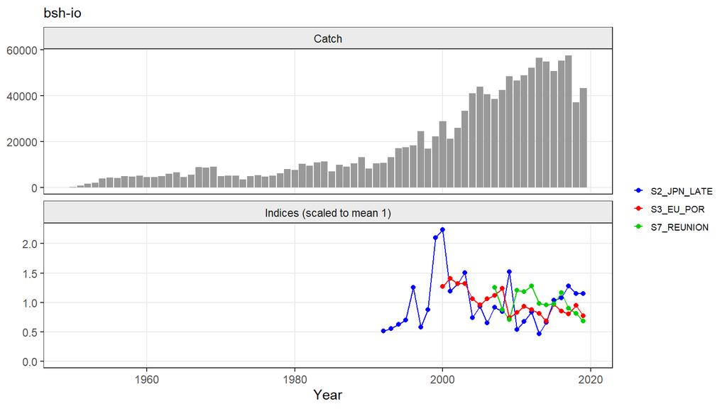

```r
jbplot_data(d)
```

No index SEs are in `smry$dg`. A floor of `se_min = 0.25` matches the 2017 runs (indices were over-precise).

# 5. Priors

From IOTC–2017–WPM08–11 for blue shark (Schaefer):

| Prior | Setting |
| --- | --- |
| Shape | Schaefer ($B_{MSY}/K = 0.5$, so $F_{MSY} = r/2$) |
| $r$ | lognormal median 0.267, CV 0.075 |
| $K$ | lognormal median 600 000 t, CV 200% |
| $B_1/K$ | lognormal median 1, CV 0.25 |
| Process variance | inverse-gamma (JABBA 2 / `sdb = "igamma"`) |

```r
pr <- jb3_priors(
  d,
  r = r_prior,
  K = K_prior,
  bkinit = psi_prior,
  sdb = sdb_prior
)
pr
```

```
## JABBA3 priors (lognormal: median, log.sd; on = 1)
##          median log.sd on
## r      2.67e-01 0.0749  1
## K      6.00e+05 1.2700  1
## bkinit 1.00e+00 0.2460  1
## sdb          NA     NA  1
## m            NA 0.3000  0
## sdi    2.00e-01 0.5000  0
## sdb: diffuse inverse-gamma(0.001, 0.001) on the variance (JABBA 2 legacy)
## q: flat on log q
## kdyn (dynamic sdb only): normal(0.27, 0.15)
```

With Schaefer, $F_{MSY} = r/2$. The tight $r$ prior therefore centres $F_{MSY}$ near 0.13–0.14, as in Table 3 of the supporting information (JABBA column).

# 6. Model and fit

```r
m <- jb3_model(
  shape = shape,
  se.min = se_min,
  start = start_pe
)
fit <- jabba3(d, pr, m, ndraws = ndraws, run = run_id)
fit
```

```
## JABBA3 fit: bsh-io IOTC-2017 priors ( bsh-io )  engine: rtmb  + 1000 mvn draws
##   model: schaefer
##   convergence: ok (max gradient 1.0e-10, Newton decrement 3.3e-22)
##   estimates (mode, 95% CI):
##             est      lci      uci
## K      9.84e+05 3.96e+05 2.44e+06
## r      2.68e-01 2.31e-01 3.10e-01
## bkinit 1.00e+00 6.17e-01 1.62e+00
## sdb    5.04e-02 1.32e-02 1.93e-01
## q1     1.07e-06 3.61e-07 3.19e-06
## q2     1.18e-06 3.83e-07 3.66e-06
## q3     1.29e-06 4.05e-07 4.08e-06
## sdi1   3.20e-01 1.99e-01 5.15e-01
## sdi2   5.63e-02 1.62e-02 1.96e-01
## sdi3   7.12e-02 1.51e-02 3.36e-01
## m      2.00e+00       NA       NA
## Bmsy   4.92e+05 1.98e+05 1.22e+06
## Fmsy   1.34e-01 1.16e-01 1.55e-01
## MSY    6.58e+04 2.67e+04 1.62e+05
##   status 2019: B/Bmsy 1.50 (1.08-2.09), F/Fmsy 0.44 (0.13-1.47)
```

# 7. Score against SS3 and the 2017 JABBA

JABBA3 saw only catch and CPUE. The SS3 biomass and $F$ trajectories were not inputs. Supporting-information Table 3 (2017 JABBA, terminal year 2015): $B/B_{MSY} \approx 1.33$, $F/F_{MSY} \approx 0.87$, MSY $\approx$ 47 300 t, $B_{MSY} \approx$ 349 000 t, $F_{MSY} \approx 0.14$.

```r
qty <- function(fit, q, year = NULL) {
  x <- fit$ts[fit$ts$quantity == q & is.finite(fit$ts$est), ]
  if (!is.null(year) && year %in% x$year) x[x$year == year, , drop = FALSE] else x[nrow(x), , drop = FALSE]
}

b_end <- qty(fit, "B/Bmsy")
f_end <- qty(fit, "F/Fmsy")
b_2015 <- qty(fit, "B/Bmsy", 2015)
f_2015 <- qty(fit, "F/Fmsy", 2015)

cell_of <- function(b, f) {
  if (!is.finite(b) || !is.finite(f)) return("unknown")
  if (b >= 1 && f <= 1) "green"
  else if (b >= 1 && f > 1) "subject to overfishing"
  else if (b < 1 && f <= 1) "overfished"
  else "overfished and subject to overfishing"
}

est_of <- function(fit, nm) {
  e <- fit$est
  if (is.null(e)) return(NA_real_)
  if (is.data.frame(e) && "par" %in% names(e)) return(e$est[match(nm, e$par)])
  if (!is.null(rownames(e)) && nm %in% rownames(e)) return(as.numeric(e[nm, "est"]))
  NA_real_
}

knitr::kable(
  data.frame(
    Source = c(
      "SS3 (smry$kb, folder end)",
      "SS3 (smry$kb, 2015)",
      "JABBA3 (this fit, end)",
      "JABBA3 (this fit, 2015)",
      "IOTC 2017 JABBA (Table 3)"
    ),
    Year = c(
      ss3_end$year, 2015,
      b_end$year, b_2015$year, 2015
    ),
    `B/Bmsy` = c(
      ss3_end$stock, ss3_2015$stock,
      b_end$est, b_2015$est, 1.33
    ),
    `F/Fmsy` = c(
      ss3_end$harvest, ss3_2015$harvest,
      f_end$est, f_2015$est, 0.87
    ),
    Cell = c(
      cell_of(ss3_end$stock, ss3_end$harvest),
      cell_of(ss3_2015$stock, ss3_2015$harvest),
      cell_of(b_end$est, f_end$est),
      cell_of(b_2015$est, f_2015$est),
      cell_of(1.33, 0.87)
    ),
    check.names = FALSE
  ),
  digits = 2
)
```

[output not shown]

```r
knitr::kable(
  data.frame(
    Quantity = c("K (t)", "r", "Bmsy (t)", "Fmsy", "MSY (t)"),
    `This fit` = c(
      est_of(fit, "K"), est_of(fit, "r"),
      est_of(fit, "Bmsy"), est_of(fit, "Fmsy"), est_of(fit, "MSY")
    ),
    `IOTC 2017 JABBA` = c(698486, 0.271, 349243, 0.135, 47356),
    check.names = FALSE
  ),
  digits = 3
)
```

| Quantity | This fit | IOTC 2017 JABBA |
| --- | --- | --- |
| K (t) | NA | 698486.000 |
| r | NA | 0.271 |
| Bmsy (t) | NA | 349243.000 |
| Fmsy | NA | 0.135 |
| MSY (t) | NA | 47356.000 |

Catch and CPUE in this SS3 folder are close to, but not identical with, the 2017 GAM series, so exact Table 3 numbers are not expected. With these priors the stock should be the same order of magnitude as the 2017 JABBA ($K$ near 0.7–1 Mt, green cell, $F_{MSY}$ near 0.14), not a multi-million-tonne Fox run with a loose $r$ prior.

# 8. Plots

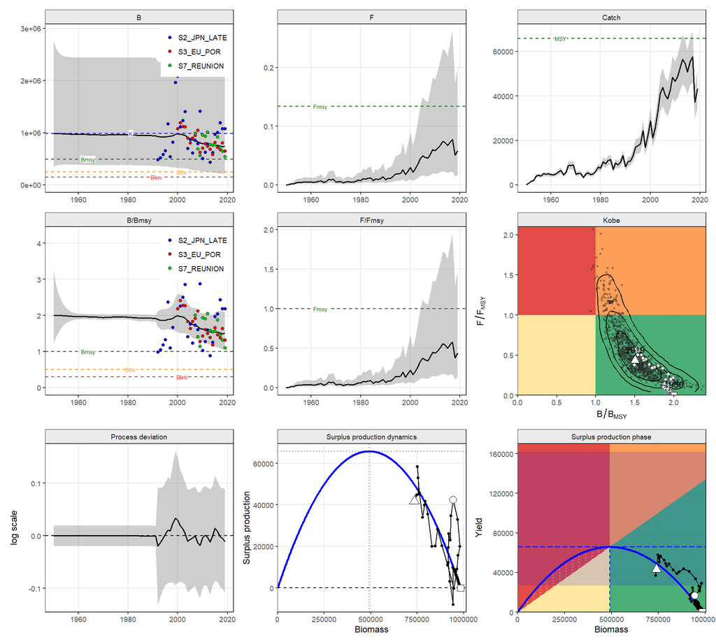

```r
plot(fit)
```

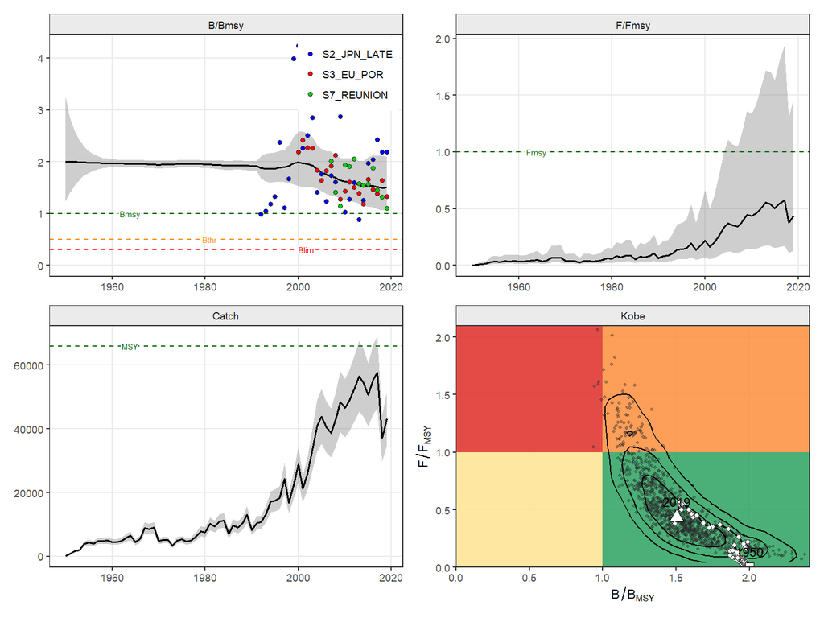

```r
plot(fit, "simple")
```

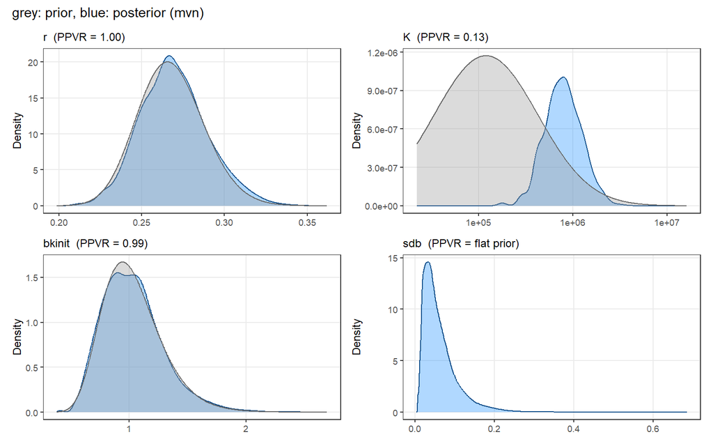

```r
jbplot_priorpost(fit)
```

# 9. Diagnostics

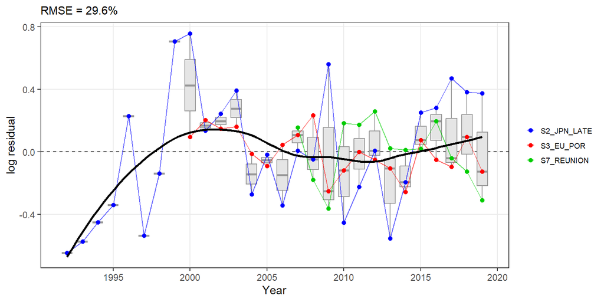

```r
jbplot_residuals(fit, type = "ordinary")
```

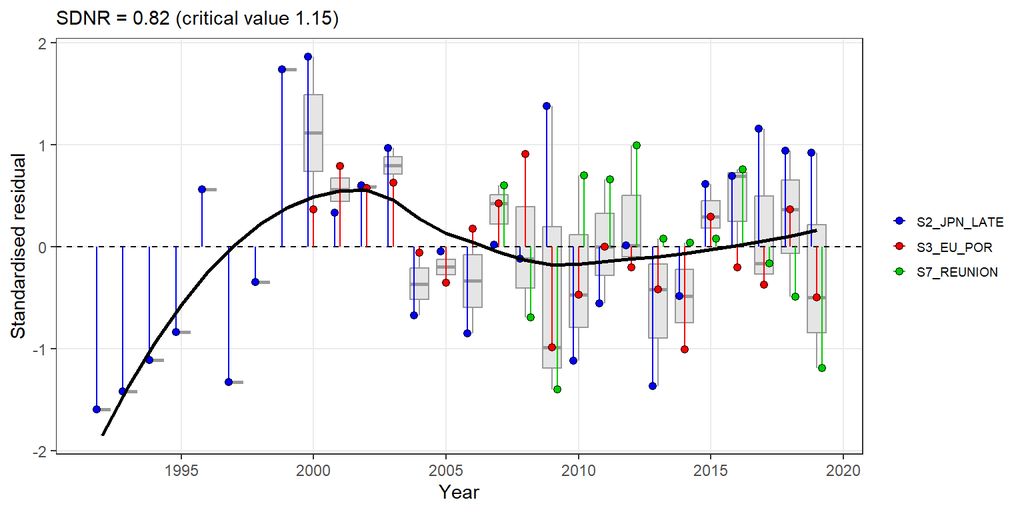

```r
jbplot_stdresiduals(fit)
```

# 10. Your stock

Copy this file. Change only what follows. Leave the section order as it is.

1. **`stock_id`** — a short name for plots and the fit print.
2. **`ss3_dir`** — folder that contains `smry.RData` with `ts`, `dg`, `kb`, and `refpts`.  
   If your SS3 run has no `smry.RData`, build `catch` and `cpue` yourself in section 3:
   - `catch`: data frame with columns `year`, `catch`
   - `cpue`: data frame with columns `year`, then one column per index (`NA` where missing)  
     and supply the SS3 terminal $B/B_{MSY}$ and $F/F_{MSY}$ for the score table.
3. **`indices`** — names of the CPUE columns to keep, or `NULL` for all. Prefer the assessment base-case set, not every series in the folder.
4. **`r_prior` / `K_prior` / `psi_prior` / `shape`** — take these from the stock’s own assessment write-up when you can (life-history $r$, vaguely informative $K$, initial depletion). For Schaefer, $F_{MSY} = r/2$; for Fox, $F_{MSY} \approx r$.
5. **`sdb_prior`**, **`se_min`**, **`start_pe`** — leave as here to stay close to classic JABBA workshop settings, or switch `sdb_prior` to `"fishlife"` for the JABBA3 default.
6. **`run_id`** — label for this run.

Then knit again. The objects you should recognise at the end are `d`, `pr`, `fit`, and the score tables.

## Checks before you leave this example

- Render this file as it stands; expect a green cell and $K$ on the order of $10^5$–$10^6$ t, not several million with $F/F_{MSY}$ near zero.
- Compare the 2015 row with supporting-information Table 3.
- Set `shape <- "fox"` and keep the same $r$ prior: note that the implied $F_{MSY}$ doubles — do not leave $r$ unchanged when you change shape.
- Only then point `ss3_dir` at another stock.